# Quantile stars objects: basic operations [updated]

```r
suppressPackageStartupMessages({
  library(dplyr)
  library(stars)
  library(sf)
  library(ggplot2) # For plotting
})

source("helper_functions.R")
# Replace this with the path to the folder containing the stars data
stars_folder <- "/mnt/ecocast/projectdata/students/ojohnson/copernicus/cfin/versions/cf.0/cf.0.01/preds/daily_resolution"
dir.exists(stars_folder)
```

```
## [1] TRUE
```

Quantile stars objects are saved to folder using the `stars::write_mdim()` function. We can read them in using `stars::read_mdim(file_path)` or by using the custom `read_quantile_stars()` method defined in `helper_functions.R`. Stars are saved as netCDF objects (“.nc” file extension)

- Each year is saved as a separate stars object.
- `write_mdim()` has optional boolean argument `as_float`. If it’s TRUE, values in the stars object are saved as floats, else they’re saved as doubles. I’m providing copies of the data with *double* values, which also doubles the file size (2.2 GB vs. 1.1 GB). However, this means that `read_mdim()` correctly interprets the stars object as having a regular dimension grid, rather than irregular values. If you choose to save an object with float values to save on storage, you can use `read_quantile_stars()` and/or `recover_interval_dims()` in `helper_functions.R` to “fix” incorrect irregular dimensions.

```r
# Read in data from 1993
example_stars <- file.path(stars_folder, "cfin_daily_resolution_1993.nc") |>
  stars::read_mdim()

# If you want to fix incorrect irregular dimensions (not necessary for the files i provided),
# pass it to recover_interval_dims()
example_stars <- recover_interval_dims(example_stars)

example_stars
```

```
## stars object with 3 dimensions and 7 attributes
## attribute(s), summary of first 1e+05 cells:
##               Min.     1st Qu.      Median       Mean    3rd Qu.      Max.
## 0%    3.309699e-05 0.003933616 0.008939636 0.02442419 0.02240868 0.8342811
## 5%    5.278809e-05 0.005509777 0.010886192 0.03258902 0.03179349 0.8434872
## 25%   1.142306e-04 0.008990593 0.017679820 0.05308458 0.05844682 0.9042338
## 50%   1.612881e-04 0.012780160 0.024871011 0.07355103 0.08912728 0.9341946
## 75%   2.358345e-04 0.019125808 0.038553350 0.10086094 0.13001773 0.9570764
## 95%   2.934622e-04 0.031369395 0.060945239 0.14201685 0.20450681 0.9811020
## 100%  3.503001e-04 0.040709719 0.083805628 0.16932776 0.24903349 0.9820987
##        NA's
## 0%    34222
## 5%    34222
## 25%   34222
## 50%   34222
## 75%   34222
## 95%   34222
## 100%  34222
## dimension(s):
##      from  to     offset    delta refsys x/y
## lon     1 415     -77.04  0.08333 WGS 84 [x]
## lat     1 261      56.71 -0.08333 WGS 84 [y]
## date    1 365 1993-01-01   1 days   Date
```

Stars objects are 3D data cubes with multiple attributes. For our case, each attribute is a quantile percentage of predictions (i.e. 0/50/100 corresponds to min/median/max of predictions across all model folds). Dimensions are specified across longitude, latitude, and date using CRS 4326. NA values correspond to land.

Stars objects can be subset using square bracket notation. They can be autoplot using the `plot()` function (ugly) or using ggplot and `geom_stars()` (less ugly).

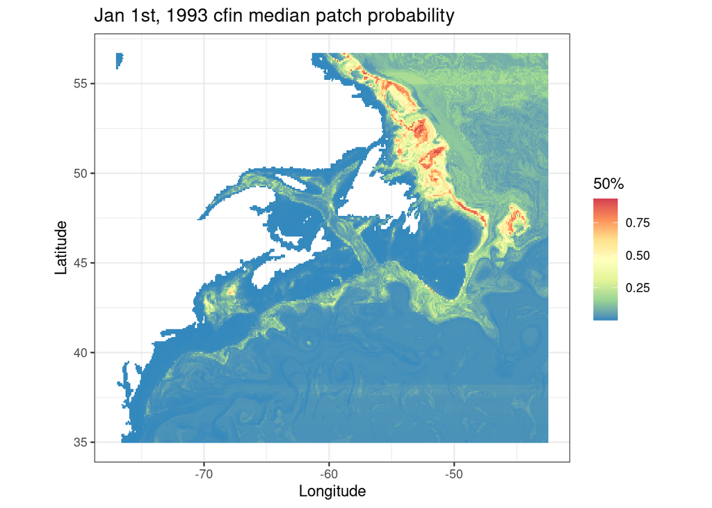

```r
# Stars_object[attribute_subset, x_subset, y_subset, date_subset]
example_50perc_Jan1 <- example_stars["50%",,,1]

basic_plot_stars <- function(stars_obj, title) {
  ggplot() +
  geom_stars(data = stars_obj) + # make sure to pass the data here, not to ggplot()!
  theme_bw() +
  coord_quickmap() +
  scale_fill_distiller(palette = "Spectral", na.value = "transparent") +
  labs(x = "Longitude", y = "Latitude", title = title)
}

basic_plot_stars(example_50perc_Jan1, "Jan 1st, 1993 cfin median patch probability")
```

Use `st_get_dimension_values()` to retrieve the actual values of any specific dimension.

```r
# Examining the first ten dates in the example stars object
st_get_dimension_values(example_stars, which = "date")[1:10]
```

```
##  [1] "1993-01-01" "1993-01-02" "1993-01-03" "1993-01-04" "1993-01-05"
##  [6] "1993-01-06" "1993-01-07" "1993-01-08" "1993-01-09" "1993-01-10"
```

It’s easy to create new attributes from scratch or based on existing attributes using similar notation to dataframes.

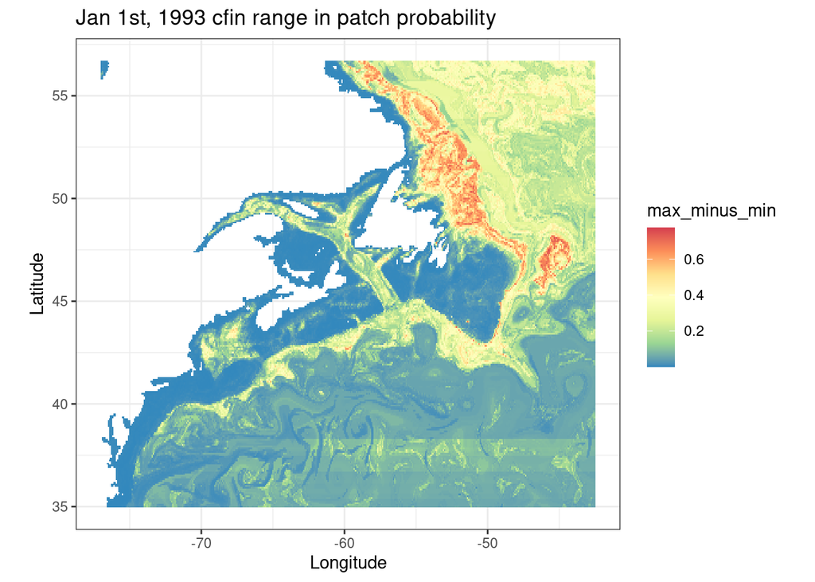

```r
example_stars$max_minus_min <- example_stars$`100%` - example_stars$`0%`

basic_plot_stars(example_stars["max_minus_min",,,1], "Jan 1st, 1993 cfin range in patch probability")
```

Stars objects can be altered to match different spatial geometries and extents using `st_crop`, `st_transform()`, and `st_warp()`.

[output not shown]

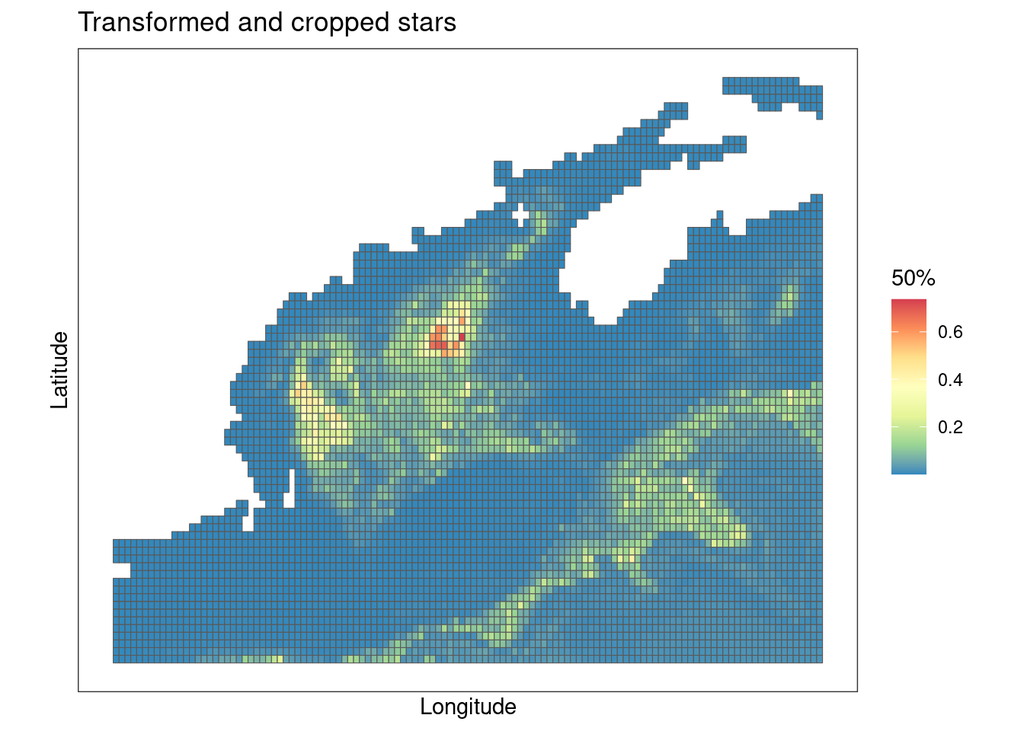

```r
# Crop extent to gulf of maine
cropped_stars <- st_crop(example_50perc_Jan1,
                         sf::st_bbox(c(xmin = -72.5, xmax = -62.5, ymin = 40, ymax = 46),
                                     crs = 4326))
# Switch coordinate system to pseudo mercator
stars_transformed_cropped <- st_transform(cropped_stars, crs = 3857)

# St_warp coerces one stars object to match another
stars_warped <- st_warp(src = example_50perc_Jan1, dest = stars_transformed_cropped)

basic_plot_stars(stars_warped, "Transformed and cropped stars") +
  coord_sf(datum = NA) # Required to plot 3857 coord system
```

Finally, stars objects can be transformed to and from data frames using `as.data.frame()` and `st_as_stars()`. Be careful with filtering out rows, it can affect retransforming back into a stars object.

```r
ex_df <- as.data.frame(example_50perc_Jan1)

head(ex_df)
```

```
##         lon      lat       date         50%
## 1 -77.00000 56.66667 1993-01-01 0.001413130
## 2 -76.91667 56.66667 1993-01-01 0.002294319
## 3 -76.83333 56.66667 1993-01-01 0.002235590
## 4 -76.75000 56.66667 1993-01-01 0.001205734
## 5 -76.66667 56.66667 1993-01-01 0.001343954
## 6 -76.58333 56.66667 1993-01-01 0.001544357
```

```r
ex_df$land_mask <- !complete.cases(ex_df)

st_as_stars(ex_df, dims = c("lon", "lat", "date"))
```

```
## stars object with 3 dimensions and 2 attributes
## attribute(s):
##       50%        land_mask
##  Min.   :0.000   Mode :logical
##  1st Qu.:0.014   FALSE:73874
##  Median :0.023   TRUE :34441
##  Mean   :0.068
##  3rd Qu.:0.079
##  Max.   :0.934
##  NA's   :34441
## dimension(s):
##      from  to offset    delta refsys     values x/y
## lon     1 415 -77.04  0.08333     NA       NULL [x]
## lat     1 261  56.71 -0.08333     NA       NULL [y]
## date    1   1     NA       NA   Date 1993-01-01
```

More resources about stars:

- [Merging stars objects (useful for combining years)](https://tmieno2.github.io/R-as-GIS-for-Economists/merging-stars-objects-using-c-and-st_mosaic.html)
- [Official stars documentation](https://r-spatial.github.io/stars/index.html)

Enjoy!